# Data Analyst Job Market Report

## Introduction

In this assignment, we used Large Language Models (LLMs) directly within Google Sheets to automatically extract structured information from approximately 400 data analysis job postings. The dataset originates from a Glassdoor project designed to analyze the Data Scientist, Data Engineer, and Data Analyst job market in June 2020. Glassdoor is an American technology and career information platform best known for allowing employees and job seekers to anonymously review companies, share salary information, and search for job opportunities. By combining features of a job search engine with a workplace review site, Glassdoor aims to help individuals make more informed career decisions. Using LLM-powered prompts embedded in Google Sheets, we extracted two key pieces of information from each job posting: the number of years of professional experience required and the programming language requirements. Specifically, we identified whether each position required proficiency in R, Python, both languages, or neither. This approach demonstrates how LLMs can be integrated into spreadsheet-based workflows to efficiently transform unstructured job descriptions into analyzable, structured data.

The dataset contains **400** job postings. After removing rows with missing salary or experience data, **309** postings are available for the experience-vs-salary analysis. The median salary estimate is **$68,000** and the median minimum years of experience requested is **3** years.

## Experience vs. Salary

The scatter plot below shows the relationship between the minimum years of experience requested and the median salary estimate (USD) across job postings.

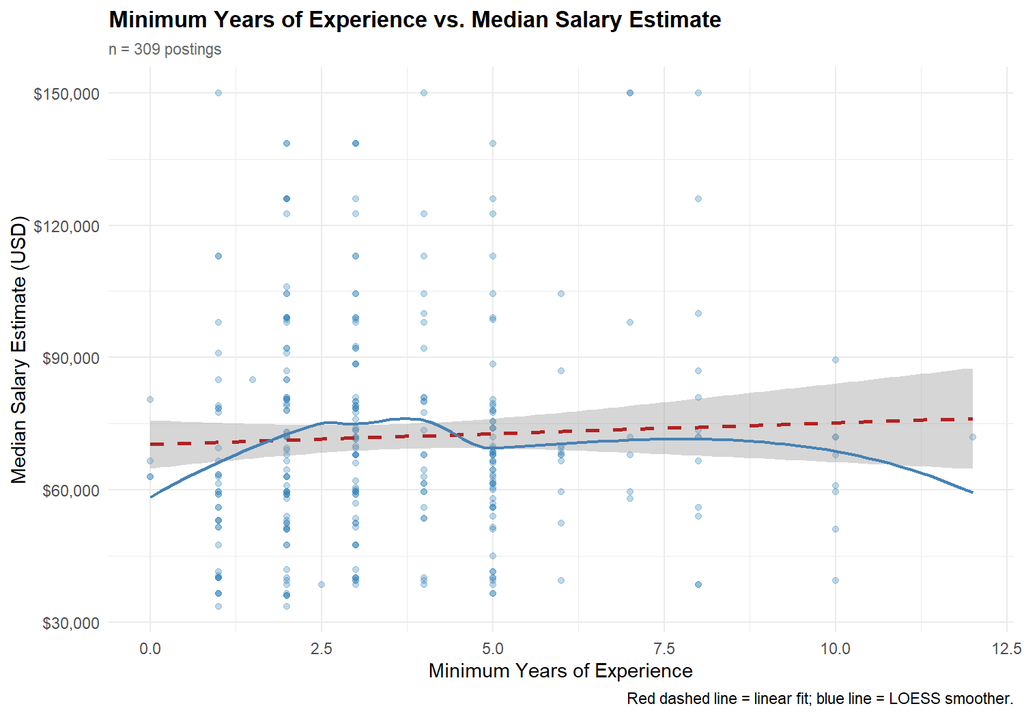

The **Pearson correlation** between minimum experience and median salary is **r = 0.042** (p = 0.464), and the **Spearman rank correlation** is **ρ = 0.065** (p = 0.258).

## Salary by Data Language

The box plot below compares the distribution of median salary estimates across the four data-language categories: R, Python, Both, and Neither.

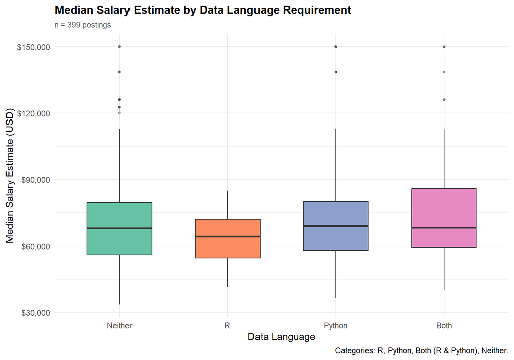

| Data Language | Count | Median | Mean | Min | Max |
| --- | --- | --- | --- | --- | --- |
| Neither | 256 | $68,000 | $70,398 | $33,500 | $150,000 |
| R | 14 | $64,250 | $64,750 | $41,500 | $85,000 |
| Python | 65 | $69,000 | $74,154 | $36,500 | $150,000 |
| Both | 64 | $68,250 | $76,094 | $40,000 | $150,000 |

Salary statistics by data-language requirement.

## Reflection

This assignment was great and I learned a lot. Integrating LLMs directly into Google Sheets to extract information from unstructured information is certainly a very useful skill! I got blocked at the beginning because I could not get Google Sheets to talk to the LLM – for some reason I did not get the request to grant permission. The more challenging aspects include ensuring consistency and accuracy in the extracted outputs, particularly when ambiguous or non-standard language is used. I am not convinced that the data are 100% correct but I am reasonably confident that the conclusions are broadly correct, although the results for experience and salary level did surprise me somewhat.